QRM: Sixth Meeting

# Research Methodology in Social Sciences

Dr. David Sichinava  
November 16, 2018

Sixth Meeting

### Today's meeting

- Comparing groups

### Dependent and independent samples

- Two samples are dependent if natural matching occurs between two groups. For instance, repeated measurements of same subjects
- Samples are independent if they are drawn *independently*.

### Compare means of two independent groups: confidence intervals

- For large samples, or small samples from random distributions the sampling distribution of \( (\bar{y}_{2}-\bar{y}_{1}) \) has a normal shape, we use *t-distribution* to estimate standard errors and confidence intervals
- Confidence interval for \( \mu_{2}-\mu_{1} \) will be:
  - \( (\bar{y}_{2}-\bar{y}_{1})+/- t(se) \), where \( se=\sqrt{\frac{{s_{1}^2}}{{n}_{1}}+\frac{{s_{2}^2}}{{n}_{2}}} \)
- Usually, interpreting differences between two groups is usually *safer* and *more interpretable* than testing null hypothesis

### Compare means of two independent groups: null hypothesis testing

- \( t=\frac{(\bar{y}_{2}-\bar{y}_{1})-0}{se} \)
- Here we compute test statistic and then look for corresponding p-value

- Fisher's exact test OR Chi-square test

### What about different scales?

[figure not shown]

### What about different scales?

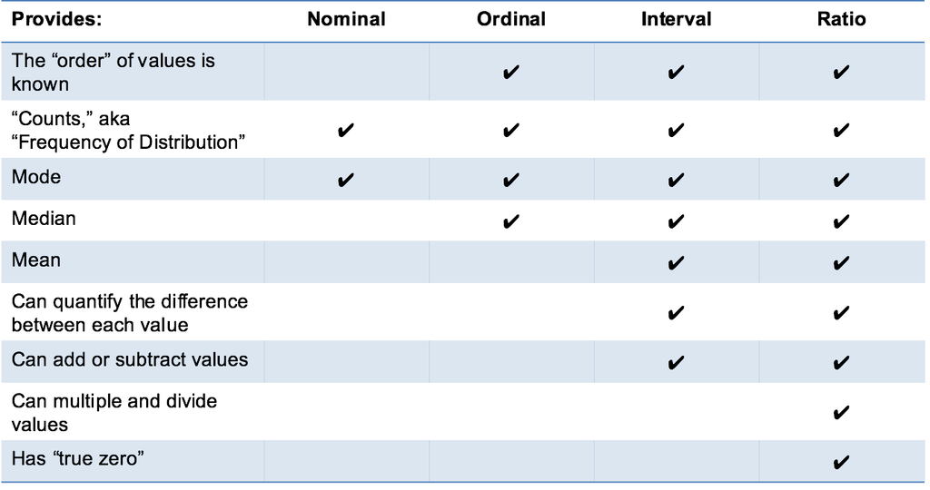

### What happens if the assumptions (of normality) are not met?

- We use non-parametric tests, such as Wilcoxon-Mann-Whitney test
  - Instead of comparing *means*, we compare *median* values